# Report for Job [KEY:SNP_SNP_Diff__aa-bb_vs_other(1)__No]

WGIA

2024-08-13 19:45:13

**You can bookmark this page to access the results later, or download the report locally.**

*Results will be stored for 30 days.*

> WGIA is an open-access web application designed for genome-wide interaction analysis. Leveraging GPU parallel technologies, it significantly enhances computational efficiency. You can upload the SNP, DNA methylation, gene expression, or other biological data, and WGIA generates a comprehensive report within a short timeframe.

# 1. Datasets information

## 1.1 marker information

**There are total 100 Single Nucleotide Polymorphism (SNP) in group1 and 100 Single Nucleotide Polymorphism (SNP) in group2 used for interaction analysis.**

- In order to provide the fullest results as possible, WGIA provided interaction for all the SNP uploaded, with out quality control for the data.
- Note: If needed, some basic information about SNP can be used to perform quality control before uploaded the datasets, such as the missing rate.

## 1.2 sample information

**There are total of 50 samples in group1 and 50 samples in group2 used for interaction calculation.** **Note: There are no other sample information be used.**

# 2. Interaction differential analysis results

## 2.1 OR statistic distribution

**The WGIA performed a total of 4,950 calculations between 100 SNP respectively in group1 and group2 for this job, encompassing OR and chi-square test among all possible SNP-SNP pairs. The resultsare displayed below.**

> **SNP×SNP Interaction (case-control):** Case-Control SNP×SNP Interaction Differential Analysis identifies differences in SNP interactions between individuals with a particular disease (cases) and those without the disease (controls). By comparing the interactions, researchers can uncover specific SNP combinations that contribute to disease susceptibility, which may not be apparent when considering single SNP effects alone.  
> **`aa*bb_vs_other:`** A 2x2 contingency table, along with the Odds Ratio (OR) and chi-square test, is utilized to evaluate the differences in SNP-SNP interactions between two sets of data. The OR value quantifies the strength of association or non-independence between tested genotype combinations and others, while the chi-square test assesses whether the observed differences are statistically significant.  
> The 2x2 contingency table used in this job was:

```
##        aa*bb other
## group2     a     b
## group1     c     d
```

- These results can be downloaded here OR distribution files.

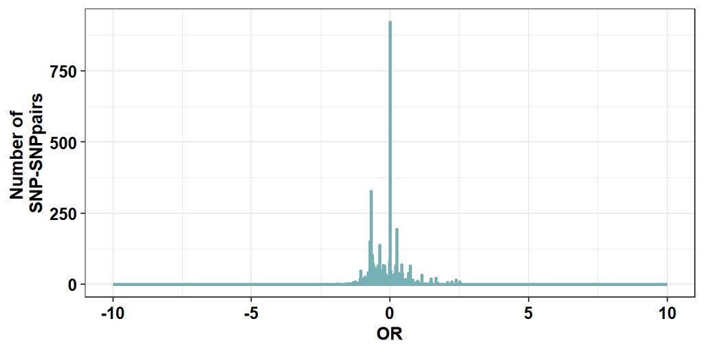

- A more rough distribution of intervals is as follows:

|  | lower_interval | upper_interval | frequent |
| --- | --- | --- | --- |
| 1 | -2 | -1 | 134 |
| 2 | -1 | 0 | 2490 |
| 3 | 0 | 1 | 2180 |
| 4 | 1 | 2 | 109 |
| 5 | 2 | 3 | 37 |

## 2.2 OR value distribution metrics

**Some basic information about the distribution is provided in the table below, including mean value, variance, standard deviation, skewness, kurtosis, median_value, lower quartile, upper quartile, interquartile range.**

- **Mean value**: The average value of the data set.
- **Variance**: A measure of how much the data points differ from the mean.
- **Standard deviation**: The square root of the variance, indicating the spread of the data.
- **Skewness**: A measure of the asymmetry of the data distribution.
- **Kurtosis**: A measure of the “tailedness” of the data distribution.
- **Median value**: The middle value that separates the higher half from the lower half of the data set.
- **Lower quartile (Q1)**: The median of the lower half of the data set (25th percentile).
- **Upper quartile (Q3)**: The median of the upper half of the data set (75th percentile).
- **Interquartile range (IQR)**: The range between the lower quartile and the upper quartile (Q3 - Q1), measuring the spread of the middle 50% of the data.
- These results can be downloaded here OR value distribution files. The last 9 line of the file are the metric values of the distribution.

|  | metrics | value |
| --- | --- | --- |
| 1 | mean value | -0.149209 |
| 2 | variance | 0.325007 |
| 3 | standard deviation | 0.570094 |
| 4 | skewness | 0.148805 |
| 5 | kurtosis | 0.044902 |
| 6 | lower quartile | -0.632095 |
| 7 | median_value | -0.141909 |
| 8 | upper quartile | 0.178109 |
| 9 | interquartile range | 0.810204 |

- These results can be downloaded here DiffChisq.txt.

  | Model | Marker1 | Marker2 | a | b | c | d | OR | Lower_CI | Upper_CI | chi_square | chi_pvalue |
  | --- | --- | --- | --- | --- | --- | --- | --- | --- | --- | --- | --- |
  | aa*bb_vs_other | rs1019916 | rs10457834 | 16.00 | 34.00 | 21.00 | 29.00 | 0.65 | 0.29 | 1.47 | 0.69 | 0.41 |
  | aa*bb_vs_other | rs1019916 | rs1416770 | 14.00 | 36.00 | 21.00 | 29.00 | 0.54 | 0.23 | 1.24 | 1.58 | 0.21 |
  | aa*bb_vs_other | rs1019916 | rs1941955 | 14.00 | 36.00 | 21.00 | 29.00 | 0.54 | 0.23 | 1.24 | 1.58 | 0.21 |
  | aa*bb_vs_other | rs1019916 | rs2125573 | 12.00 | 38.00 | 18.00 | 32.00 | 0.56 | 0.24 | 1.34 | 1.19 | 0.28 |
  | aa*bb_vs_other | rs1019916 | rs2235751 | 24.00 | 26.00 | 22.00 | 28.00 | 1.17 | 0.53 | 2.58 | 0.04 | 0.84 |
  | aa*bb_vs_other | rs1019916 | rs2521373 | 24.00 | 26.00 | 21.00 | 29.00 | 1.27 | 0.58 | 2.81 | 0.16 | 0.69 |

- If you need the full results, Please perform the interaction analysis with our local software WGIA.exe